# **Regresión Lineal Multivariada (I)**

Profesor: [Dr. José Manuel MAGALLANES REYES, Ph.D.](http://www.pucp.edu.pe/profesor/jose-manuel-magallanes/)

Editors: [Gianfranco Romero](https://github.com/GianfrancoRomero), a20196091@pucp.edu.pe & [Joel Hu](https://github.com/luccemhu), a20196510@pucp.edu.pe

2023-07-26

# Más allá de la Regresión Lineal (OLS)

Utilicemos los datos del INEI: XI Censo de Población y VI Censo de Vivienda del 2007.

Indicadores a nivel de distrito (por departamento y provincia):

- Número de personas que tienen algún tipo de seguro. `segu`
- Porcentaje de Trabajadores Independientes o por cuenta propia no profesionales. `inde`
- Porcentaje de personas analfabetas de 15 años y más. `analf15`
- Total de habitantes (2007). `pob`

```r
#rm(list = ls()) # clear memory
#knitr::knit_hooks$set(inline = as.character) # inline as string

gitLink = "https://github.com/luccemhu/EDIT-Clases-E2/raw/main/sesion-3/salud.xlsx"
salud = rio::import(gitLink)

# simpler names
oldnames = names(salud)
newnames = c("depa", "prov", "dis", "segu", "inde", "analf15", "pob")
names(salud) = newnames

# display table
#library(magrittr) # needed for pipe |>
#salud |> rmarkdown::paged_table()
```

Por ejemplo:

> H1: A nivel distrital, la cantidad de personas con algún seguro de salud `segu` está afectada por el nivel analfabetismo `analf15`.

Podríamos intentar una regresión lineal:

```r
library(knitr)
library(modelsummary)

h1 = formula(segu ~ analf15)
rl1 = lm(h1, data = salud)

model1 = list('OLS asegurados (I)' = rl1)
modelsummary(model1, title = "Resumen de Regresion Lineal",
             stars = TRUE, output = "kableExtra")
```

Resumen de Regresion Lineal

|  | OLS asegurados (I) |
| --- | --- |
| (Intercept) | 12397.369*** |
|  | (748.564) |
| analf15 | -444.967*** |
|  | (45.970) |
| Num.Obs. | 1831 |
| R2 | 0.049 |
| R2 Adj. | 0.048 |
| AIC | 40986.3 |
| BIC | 41002.8 |
| Log.Lik. | -20490.143 |
| F | 93.694 |
| RMSE | 17531.34 |

+ p < 0.1, * p < 0.05, ** p < 0.01, *** p < 0.001

- El **covariado** salió con un valor absoluto alto, negativo, y significativo (es muy poco probable - menos de 0.1% - que no tenga efecto), pero con un **R-2 ajustado muy bajo**. Como el modelo no nos da buen *ajuste*, es muy probable que la evaluación del modelo no sea satisfactoria. Comprobamos con los diagnósticos de regresión que difícilmente este modelo puede ser útil:

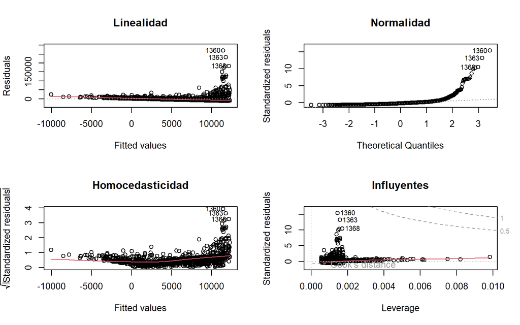

Diagnósticos para el modelo OLS asegurados (I)

```r
par(mfrow = c(2, 2))
plot(rl1, 1,caption = ''); title(main = "Linealidad")
plot(rl1, 2, caption = ''); title(main = "Normalidad")
plot(rl1, 3, caption = ''); title(main = "Homocedasticidad")
plot(rl1, 5, caption = ''); title(main = "Influyentes")
```

Podríamos mejorar este modelo si controlásemos el tamaño de la población (`pob`) en el modelo:

```r
library(knitr)
library(modelsummary)

h1control = formula(segu ~ analf15 + pob) # Añadimos la variable constante `pob`

rl2 = lm(h1control, data = salud)

modelslm = list('OLS asegurados (I)' = rl1,
                'OLS asegurados (II)' = rl2)
modelsummary(modelslm, title = "Regresiones Lineales",
             stars = TRUE, output = "kableExtra")
```

Regresiones Lineales

|  | OLS asegurados (I) | OLS asegurados (II) |
| --- | --- | --- |
| (Intercept) | 12397.369*** | 710.956*** |
|  | (748.564) | (189.771) |
| analf15 | -444.967*** | -12.293 |
|  | (45.970) | (11.186) |
| pob |  | 0.387*** |
|  |  | (0.002) |
| Num.Obs. | 1831 | 1831 |
| R2 | 0.049 | 0.946 |
| R2 Adj. | 0.048 | 0.946 |
| AIC | 40986.3 | 35719.9 |
| BIC | 41002.8 | 35742.0 |
| Log.Lik. | -20490.143 | -17855.965 |
| F | 93.694 | 16156.363 |
| RMSE | 17531.34 | 4159.25 |

+ p < 0.1, * p < 0.05, ** p < 0.01, *** p < 0.001

- Se ve una gran mejora en el R-2 ajustado con el modelo II.

Sus gráficas de diagnóstico muestran un mejor escenario (*el chunk de abajo*), pero nuestro predictor dejó de ser significativo ante la presencia de la variable de control `pob`. **Quiza *primero* debimos analizar la naturaleza de la V. Dependiente `segu`**:

```r
# Diagnósticos para el modelo OLS asegurados (II):
par(mfrow = c(2, 2))
plot(rl2, 1,caption = '');title(main = "Linealidad")
plot(rl2, 2, caption = '');title(main = "Normalidad")
plot(rl2, 3, caption = '');title(main = "Homocedasticidad")
plot(rl2, 5, caption = '');title(main = "Influyentes")
```

[output not shown]

Histograma de la V.D `segu`:

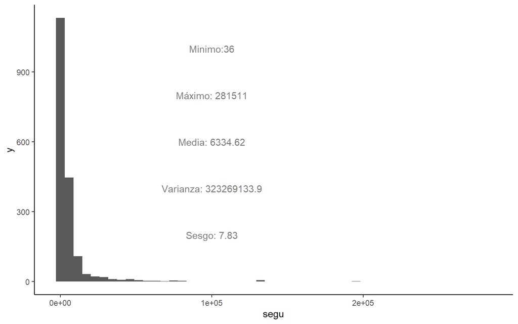

Descripción de la Variable Dependiente

```r
library(ggplot2)
VarDep = salud$segu
descris = list(min = min(VarDep),
               max = max(VarDep),
               media = round(mean(VarDep), 2),
               var = round(var(VarDep), 2),
               asim = round(e1071::skewness(VarDep), 2))

base = ggplot(data = salud, aes(x = segu)) + theme_classic()
hist = base + geom_histogram(bins = 50)

histInfo = hist + annotate("text", x = 100000, y = 1000,
                           color='grey50',
                           label = paste0("Minimo:",descris$min))
histInfo = histInfo + annotate("text", x = 100000, y = 800,
                               color = 'grey50',
                               label = paste0("Máximo: ", descris$max))
histInfo = histInfo + annotate("text", x = 100000, y = 600,
                               color = 'grey50',
                               label = paste0("Media: ", descris$media))
histInfo = histInfo + annotate("text", x = 100000, y = 400,
                               color = 'grey50',
                               label = paste0("Varianza: ", descris$var))
histInfo = histInfo + annotate("text", x = 100000, y = 200,
                               color = 'grey50',
                               label = paste0("Sesgo: ", descris$asim))
histInfo
```

- 1. El histograma nos muestra una distribución con **sesgo positivo (a la derecha)**. Es decir, **no forma una campana de Gauss**, por ello, debilitaría los calculos de significancia si los datos **no siguen una tendencia lineal**. (Se puede transformar la V.D., pero la interpretación sería compleja).
- 2. Advertimos que nuestra **V.D. representa conteos**: valores enteros positivos (*no decimales*). Por ello, la regresión lineal tuvo problemas, ya que asume que la V.D. tiene valores reales (*valores + y -*) y no acotados ().

# **Regresión Poisson [RP]**

- Se utiliza cuando el resultado es una variable de conteo *Y*, como el número de eventos que ocurren en un período de tiempo o en un área determinada.

Ahora, usemos la RP en la H1:

- comparándolos con el resultado de la regresión lineal controlada por la población:

```r
rp1 = glm(h1, data = salud,
        offset = log(pob), # Exposure # Variable control
        family = poisson(link = "log")) # Poisson

# displaying results
modelslmpoi = list('OLS asegurados (II)' = rl2,
                   'POISSON asegurados' = rp1)

modelsummary(modelslmpoi, title = "Regresiones OLS y Poisson",
             stars = TRUE,
             output = "kableExtra")
```

Regresiones OLS y Poisson

|  | OLS asegurados (II) | POISSON asegurados |
| --- | --- | --- |
| (Intercept) | 710.956*** | -0.900*** |
|  | (189.771) | (0.000) |
| analf15 | -12.293 | 0.005*** |
|  | (11.186) | (0.000) |
| pob | 0.387*** |  |
|  | (0.002) |  |
| Num.Obs. | 1831 | 1831 |
| R2 | 0.946 |  |
| R2 Adj. | 0.946 |  |
| AIC | 35719.9 | 895923.3 |
| BIC | 35742.0 | 895934.4 |
| Log.Lik. | -17855.965 | -447959.669 |
| F | 16156.363 | 21585.036 |
| RMSE | 4159.25 | 4353.10 |

+ p < 0.1, * p < 0.05, ** p < 0.01, *** p < 0.001

el modelo Poisson le devuelve efecto a la independiente. Nótese que la Poisson está modelando los conteos, teniendo en cuenta la exposición (*exposure*), añadida usando *offset*. Esto no siempre es necesario, pero en este caso si lo era pues necesitamos representar/controlar la *exposure* de manera explícita (la población) (No sería diferente si tuvieramos *hijos por hogar*, *postulaciones por político*).

La Tabla muestra dos modelos que no se pueden comparar fácilmente, pero podemos verlo de manera gráfica:

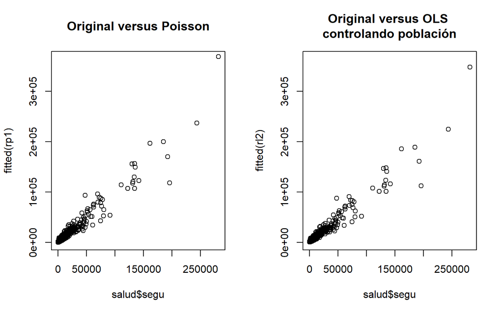

Comparando modelos via valores calculados

```r
par(mfrow = c(1, 2))  # divide screen 1 row 2 columns
plot(salud$segu, fitted(rp1),
     ylim = c(0, 365000));title(main = "Original versus Poisson")
plot(salud$segu, fitted(rl2),
     ylim = c(0, 365000));title(main = "Original versus OLS \ncontrolando población")
```

La Figura muestra que los valores obtenidos por la regresiones (*fitted values*) se relacionan muy bien con los valores originales. Ambas servirían para predecir; pero sólo la Poisson le da significancia al predictor de interés.

## Interpretación

Ahora alteremos la H1 así:

> H2: A nivel distrital en el 2007, **la cantidad de personas `pob`** con algun seguro de salud `segu` está afectada por el nivel analfabetismo `analf15` y por la presencia de trabajadores independientes `inde`.

Corolario RP hipotesis: espacio / tiempo + V. constante + V.D. + V.I…

```r
h2 = formula(segu ~ analf15 + inde)

rp2 = glm(h2, data = salud,
          offset = log(pob),
          family = poisson(link = "log"))

modelsPois = list('POISSON asegurados (I)' = rp1,
                  'POISSON asegurados (II)' = rp2)
modelsummary(modelsPois,
             title = "Regresiones Poisson anidadas",
             stars = TRUE,
             output = "kableExtra")
```

Regresiones Poisson anidadas

|  | POISSON asegurados (I) | POISSON asegurados (II) |
| --- | --- | --- |
| (Intercept) | -0.900*** | -0.615*** |
|  | (0.000) | (0.001) |
| analf15 | 0.005*** | 0.016*** |
|  | (0.000) | (0.000) |
| inde |  | -0.011*** |
|  |  | (0.000) |
| Num.Obs. | 1831 | 1831 |
| AIC | 895923.3 | 771399.1 |
| BIC | 895934.4 | 771415.6 |
| Log.Lik. | -447959.669 | -385696.535 |
| F | 21585.036 | 75214.880 |
| RMSE | 4353.10 | 3748.51 |

+ p < 0.1, * p < 0.05, ** p < 0.01, *** p < 0.001

La interpretación NO es tan directa como lo era en la regresión lineal. Sin hacer ningun cálculo, aquí podemos ver:

- que para el segundo modelo ambos predictores son significativos;
- que a mayor analfabetismo, mayor cantidad de asegurados;
- que a mayor cantidad de trabajadores independientes, menor cantidad de asegurados.

Sin embargo, no es tan sencilla la interpretación de los coeficientes. Para tener una mejor idea, debemos hacer cálculos.

Tengamos primero en cuenta lo que la regresión Poisson ha calculado usando la Ecuación:

$$\begin{equation}
\log(Y) = \log(\lambda) =\alpha + \beta \cdot X + \epsilon
\end{equation}$$

Cuando el *exposure* es constante modelamos conteos (Y); cuando no lo es modelamos ratios ($\lambda$) (los conteos con *offset*). Pero, como vemos en la Ecuación, los coeficiente necesitan ser exponenciados para saber el efecto sobre Y. Veamos la Tabla:

```r
#cbind(exp(coef(rp2)),exp(confint(rp2))) # Simple version
f <- function(x) format(x, digits = 4, scientific = FALSE)
modelsummary(modelsPois, fmt = f,
             exponentiate = T, statistic = 'conf.int',
             title = "EXP() de la Regresión Poisson para Interpretación",
             stars = TRUE, output = "kableExtra")
```

EXP() de la Regresión Poisson para Interpretación

|  | POISSON asegurados (I) | POISSON asegurados (II) |
| --- | --- | --- |
| (Intercept) | 0.4066*** | 0.5405*** |
|  | [0.4063, 0.4069] | [0.5396, 0.5415] |
| analf15 | 1.0051*** | 1.0166*** |
|  | [1.0050, 1.0051] | [1.0165, 1.0167] |
| inde |  | 0.9893*** |
|  |  | [0.9893, 0.9894] |
| Num.Obs. | 1831 | 1831 |
| AIC | 895923.3 | 771399.1 |
| BIC | 895934.4 | 771415.6 |
| Log.Lik. | -447959.669 | -385696.535 |
| F | 21585.036 | 75214.880 |
| RMSE | 4353.10 | 3748.51 |

+ p < 0.1, * p < 0.05, ** p < 0.01, *** p < 0.001

Para ello:

- 1. Identificamos el exp(coef1): 1.0166
- 2. Es mayor a 1: un incremento de una unidad en la V.I. *X* está asociado con un aumento en el número de eventos esperados (variable de conteo Y) en un cierto porcentaje.
- 3. (100x|1-1.016|) = 1.6

COEFICIENTE < 1 = DISMINUYE

- por cada unidad que aumente los trabajadores independientes, la cantidad esperada de asegurados se multiplica por 0.99, es decir, disminuiría en 1% (100x|1-0.99|) [Choueiry 2022]. Nótese que esta regresión propone un efecto multiplicativo sobre el valor medio de la respuesta (la regresión OLS o Gaussiana propone un efecto aditivo).
  - Podemos guiarnos del signo negativo del coeficiente sin exponenciar para advertir la relacion inversa. O también si el coeficiente exponenciado es menor que 1.

# Equidispersión

Uno de los supuestos en la Regresión Poisson es que la **media** y la **varianza** sean iguales. De los estadigrafos de la Figura del histograma de la V.D. se mostró que estos valores no están cercanos: La razón entre la media y la varianza es 51032.13: sobredispersión.

Comprobemos esto con la *hipótesis de equidispersion*:

```r
overdispersion = AER::dispersiontest(rp2, alternative = 'greater')$p.value <
  0.05
underdispersion = AER::dispersiontest(rp2, alternative = 'less')$p.value <
  0.05
# tabla
testResult = as.data.frame(rbind(overdispersion, underdispersion))
names(testResult) = 'Es probable?'

testResult |> kable(caption = "Test de Equidispersión") |>
  kableExtra::kable_styling()
```

Test de Equidispersión

|  | Es probable? |
| --- | --- |
| overdispersion | TRUE |
| underdispersion | FALSE |

La Tabla muestra que es altamente improbable que la varianza sea igual a la media, por lo que se opta por aceptar que lo más probable es que tengamos sobredispersión…

## La Quasi Poisson

- La presencia de sobredispersión puede tratarse con la *quasipoisson*:

```r
rqp = glm(h2, data = salud, offset = log(pob),
          family = quasipoisson(link = "log"))

modelsPQP=list('POISSON asegurados (II)' = rp2,
               'QUASIPOISSON asegurados (II)' = rqp)

modelsummary(modelsPQP, title = "Regresiones Poisson y QuasiPoisson",
             stars = TRUE, output = "kableExtra")
```

Regresiones Poisson y QuasiPoisson

|  | POISSON asegurados (II) | QUASIPOISSON asegurados (II) |
| --- | --- | --- |
| (Intercept) | -0.615*** | -0.615*** |
|  | (0.001) | (0.018) |
| analf15 | 0.016*** | 0.016*** |
|  | (0.000) | (0.001) |
| inde | -0.011*** | -0.011*** |
|  | (0.000) | (0.001) |
| Num.Obs. | 1831 | 1831 |
| AIC | 771399.1 |  |
| BIC | 771415.6 |  |
| Log.Lik. | -385696.535 |  |
| F | 75214.880 | 179.984 |
| RMSE | 3748.51 | 3748.51 |

+ p < 0.1, * p < 0.05, ** p < 0.01, *** p < 0.001

la Tabla nos muestra cosas interesantes:

- Los coeficientes son los mismos para ambos modelos:

```r
library(arm)
cbind(coefPoi = coef(rp2), coefQuasiPoi = coef(rqp))
```

```
##                 coefPoi coefQuasiPoi
## (Intercept) -0.61523114  -0.61523114
## analf15      0.01649913   0.01649913
## inde        -0.01073999  -0.01073999
```

- Pero no los errores típicos no:

```r
cbind(sePoi = se.coef(rp2), seQuasiPoi = se.coef(rqp))
```

```
##                    sePoi   seQuasiPoi
## (Intercept) 8.910449e-04 0.0182152135
## analf15     4.609011e-05 0.0009421985
## inde        3.037210e-05 0.0006208826
```

- Nota además ambos modelos tienen diferente parámetro de dispersion:

```r
summary(rqp)$dispersion; summary(rp2)$dispersion
```

```
## [1] 417.8971
```

```
## [1] 1
```

La regresión quasipoisson lidia mejor con la sobredispersión, cuyo efecto concreto fue sobre los errores típicos, lo que afectaría la significancia de los predictores. De ahí que un mejor intervalo de confianza sería:

```r
modelsQPexp=list('QuasiPoisson asegurados (II) exponenciado'=rqp)

f <- function(x) format(x, digits = 4, scientific = FALSE)
modelsummary(modelsQPexp, fmt = f,
             exponentiate = T,
             statistic = 'conf.int',
             title = "EXP() de la Regresión Quasi Poisson (II) para Interpretación",
             stars = TRUE,
             output = "kableExtra")
```

EXP() de la Regresión Quasi Poisson (II) para Interpretación

|  | QuasiPoisson asegurados (II) exponenciado |
| --- | --- |
| (Intercept) | 0.5405*** |
|  | [0.5215, 0.5601] |
| analf15 | 1.0166*** |
|  | [1.0148, 1.0185] |
| inde | 0.9893*** |
|  | [0.9881, 0.9905] |
| Num.Obs. | 1831 |
| F | 179.984 |
| RMSE | 3748.51 |

+ p < 0.1, * p < 0.05, ** p < 0.01, *** p < 0.001

## La Binomial Negativa

Otra alternativa ante la sobredispersión es usar la *regresión binomial negativa*. Comparemos todas la regresiones exponenciadas, como se ve en la Tabla:

```r
h2off = formula(segu ~ analf15 + inde + offset(log(pob)))
rbn = glm.nb(h2off, data = salud)

modelsQP_BN = list('Poisson asegurados (II)' = rp2,
                   'QuasiPoisson asegurados (II)' = rqp,
                   'Binomial Negativa asegurados (II)' = rbn)

f <- function(x) format(x, digits = 4, scientific = FALSE)
modelsummary(modelsQP_BN, fmt = f, exponentiate = T,
             statistic = 'conf.int',
             title = "EXP() de la Regresiones Poisson, Quasi Poisson  y Binomial Negativa",
             stars = TRUE, output = "kableExtra")
```

EXP() de la Regresiones Poisson, Quasi Poisson y Binomial Negativa

|  | Poisson asegurados (II) | QuasiPoisson asegurados (II) | Binomial Negativa asegurados (II) |
| --- | --- | --- | --- |
| (Intercept) | 0.5405*** | 0.5405*** | 0.4485*** |
|  | [0.5396, 0.5415] | [0.5215, 0.5601] | [0.4271, 0.4711] |
| analf15 | 1.0166*** | 1.0166*** | 1.0142*** |
|  | [1.0165, 1.0167] | [1.0148, 1.0185] | [1.0122, 1.0162] |
| inde | 0.9893*** | 0.9893*** | 0.9951*** |
|  | [0.9893, 0.9894] | [0.9881, 0.9905] | [0.9940, 0.9963] |
| Num.Obs. | 1831 | 1831 | 1831 |
| AIC | 771399.1 |  | 29080.4 |
| BIC | 771415.6 |  | 29102.5 |
| Log.Lik. | -385696.535 |  | -14536.206 |
| F | 75214.880 | 179.984 | 106.748 |
| RMSE | 3748.51 | 3748.51 | 4011.51 |

+ p < 0.1, * p < 0.05, ** p < 0.01, *** p < 0.001

# Comparación de modelos

Para la comparación podemos usar el anova, esta vez pidiendo un test chi-cuadrado; veamos el resultado en la Tabla:

```r
anova(rp2, rqp, rbn, test = "Chisq") |>
  kable(caption = "Tabla ANOVA para comparar modelos") |>
  kableExtra::kable_styling(full_width = FALSE)
```

Tabla ANOVA para comparar modelos

| Resid. Df | Resid. Dev | Df | Deviance | Pr(>Chi) |
| --- | --- | --- | --- | --- |
| 1828 | 754118.559 | NA | NA | NA |
| 1828 | 754118.559 | 0 | 0.0 | NA |
| 1828 | 1868.019 | 0 | 752250.5 | NA |

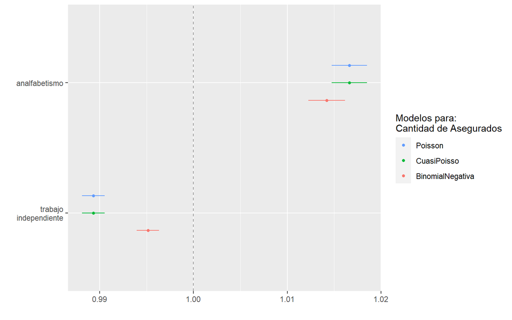

Comparación visual de modelos

```r
library(ggplot2)
dotwhisker::dwplot(list(Poisson = rqp,
                        CuasiPoisso = rqp,
                        BinomialNegativa = rbn), exp = T) +
  scale_y_discrete(labels = c("trabajo\nindependiente", "analfabetismo")) +
  scale_color_discrete(name = "Modelos para:\nCantidad de Asegurados") +
  geom_vline(xintercept = 1, colour = "grey60", linetype = 2)
```

```r
sdVD = sd(salud$segu)
sdVIs = apply(salud[, c("analf15", "inde")], 2, sd)
DF = list(Poisson = sdVIs * coef(rp2)[c(2, 3)] / sdVD,
          CuasiPoisson = sdVIs * coef(rqp)[c(2, 3)] / sdVD,
          BinomNegativa = sdVIs * coef(rbn)[c(2, 3)] / sdVD) |>
  data.frame()

DF |> kable(caption =
              "Coeficientes Standarizados (ordenar vía valores absolutos)") |>
  kableExtra::kable_styling(full_width = F)
```

Coeficientes Standarizados (ordenar vía valores absolutos)

|  | Poisson | CuasiPoisson | BinomNegativa |
| --- | --- | --- | --- |
| analf15 | 8.2e-06 | 8.2e-06 | 7.0e-06 |
| inde | -8.4e-06 | -8.4e-06 | -3.8e-06 |

Comienzo